← All reports

# 15 · Weekly report — week ending Thu 2026-10-01

**Questions.** (1) Full view of the no-ads *sale* pack removal (v32, live 2026-09-21). (2) What the China install spike did. (3) Why ad revenue is low. (4) Where IAP and retention stand.

**Project** `tiny-knightfall-idle-rpg-game.analytics_538412813` (GA4 export, `events_intraday_*`) · **run** 2026-10-02 · follows `14_no_ads_sale_removal_impact.ipynb` (2026-09-25 early read).

**Definitions**

- **Weeks run Fri → Thu.** *This week* = 09-25 … 10-01. Today (10-02) is partial and excluded.
- **Pre-removal baseline** = the two weeks 09-04 … 09-17 (before the removal, before the China spike).
- **IAP $** = `event_value_in_usd` on `in_app_purchase` — gross, VAT-inclusive outside the US, no refunds. **Ad $** = `value` on `ad_impression_MAX` (impression-level revenue reported by AppLovin MAX).
- **No-ads $** = any `skip.ad*` SKU; **sale** = the `.sale` variants removed in v32.
- **China** = `geo.country = 'China'`; reported separately and excluded from per-install comparisons.
- **Data gap:** almost no events arrive between **09-28 09:00 and 09-29 03:00 UTC** (~18 h; section 0). 09-28 is understated for every metric; retention cells whose target day is 09-28 are excluded.

Two cached extracts drive everything below (4.7 + 3.2 GiB, SQL in `notebooks/sql/`).

## TL;DR

|  | baseline (09-04 & 09-11 wks avg) | this week (09-25 … 10-01) |
| --- | --- | --- |
| total revenue | $1,445 | **$710** (−51%) |
| IAP / ads | $1,323 / $122 | $597 / $113 |
| DAU (ex-China) | 856 | 527 |
| new installs (ex-China) | ~1,820 | 926 |
| D1 retention (ex-China) | 25.9–26.6% | **20.9%** |

1. **Revenue halved mainly because there are fewer players** (UA campaigns ended), plus the sale pack removal. The removal costs ~$65–85/week net per new install, after other purchases make up part of it.
2. **China spike = zero revenue** (no Play billing or ads there), old v29 APK. Exclude from KPIs.
3. **Ad revenue is low on reach, not price:** opt-in rewarded only, 8.6% of DAU watch, eCPM $57. 20% of ad rewards are paid with no ad shown — a dev check worth ~+50% ad revenue.
4. **D1 dropped ~5 pts with v34, across every campaign** — check v34.
5. **18 h data gap on 09-28.**

```
Reusing cached data: C:\Users\Admin\Desktop\TinyKnight\parquet\nb15_user_day_facts.parquet
Reusing cached data: C:\Users\Admin\Desktop\TinyKnight\parquet\nb15_user_history.parquet
```

```
60,694 user-days, 26,523 users, 2026-08-01 .. 2026-10-01
```

## 0 · Scoreboard — the last six weeks

The 09-18 week contains the China spike (≈135 extra DAU, $0 revenue). This week is the first full week with the sale packs gone from every new install.

|  | 08-21 | 08-28 | 09-04 | 09-11 | 09-18 | 09-25 |
| --- | --- | --- | --- | --- | --- | --- |
| DAU (all) | 1182.0 | 969.0 | 899.0 | 824.0 | 776.0 | 560.0 |
| DAU China | 18.0 | 7.0 | 5.0 | 6.0 | 136.0 | 33.0 |
| installs (all) | 3086 | 1968 | 1974 | 1718 | 1754 | 1025 |
| installs China | 75 | 25 | 15 | 30 | 635 | 99 |
| IAP $ | 1341.0 | 1544.0 | 1349.0 | 1298.0 | 878.0 | 597.0 |
| no-ads $ | 477.0 | 508.0 | 513.0 | 515.0 | 145.0 | 131.0 |
| of which .sale $ | 389.0 | 363.0 | 321.0 | 302.0 | 50.0 | 0.0 |
| other IAP $ | 864.0 | 1036.0 | 836.0 | 783.0 | 732.0 | 466.0 |
| ad $ | 172.0 | 129.0 | 98.0 | 146.0 | 121.0 | 113.0 |
| total $ | 1513.0 | 1673.0 | 1448.0 | 1443.0 | 999.0 | 710.0 |
| payers | 100 | 84 | 67 | 56 | 40 | 37 |
| IAP ARPDAU ex-CN | 0.165 | 0.229 | 0.216 | 0.227 | 0.196 | 0.162 |
| ad ARPDAU ex-CN | 0.021 | 0.019 | 0.016 | 0.025 | 0.027 | 0.031 |

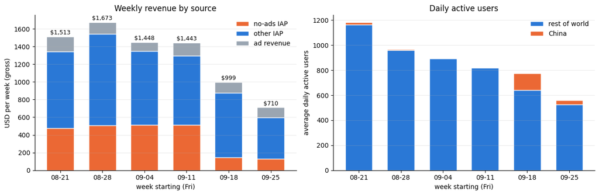

### The 09-28 data gap

Events per hour around it — this is why 09-28 looks like a half-day everywhere. Ask the dev team whether there was a server/login outage; if not, it is an export gap and the revenue in it is missing from GA4 (Play Console would still have it).

```
Reusing cached data: C:\Users\Admin\Desktop\TinyKnight\parquet\nb15_gap_hourly.parquet
```

| hr | 09-28 06 | 09-28 07 | 09-28 08 | 09-28 09 | 09-28 10 | 09-28 11 | 09-28 18 | 09-28 23 | 09-29 00 | 09-29 01 | 09-29 02 | 09-29 03 | 09-29 04 | 09-29 05 |
| --- | --- | --- | --- | --- | --- | --- | --- | --- | --- | --- | --- | --- | --- | --- |
| n | 2256 | 1849 | 3486 | 239 | 73 | 510 | 1 | 24 | 8 | 143 | 163 | 2529 | 3260 | 3045 |
| u | 67 | 55 | 59 | 30 | 7 | 5 | 1 | 6 | 5 | 5 | 11 | 38 | 48 | 54 |

## 1 · The no-ads sale pack removal — full view

### 1a · Store-level: what disappeared each week

|  | sale_buys | sale_usd | full_noads_buys | full_noads_usd | noads_usd | no-ads taps per 1k DAU |
| --- | --- | --- | --- | --- | --- | --- |
| 09-04 | 29 | 321.0 | 18 | 192.0 | 513.0 | 12.0 |
| 09-11 | 25 | 302.0 | 9 | 213.0 | 515.0 | 10.0 |
| 09-18 | 4 | 50.0 | 5 | 96.0 | 145.0 | 9.0 |
| 09-25 | 0 | 0.0 | 6 | 131.0 | 131.0 | 23.0 |

### 1b · Per new install — offer present vs offer absent

Same design as notebook 14, now with ~2 weeks of post-removal installs.

- **offer present** = installs 09-10 … 09-20 (all live builds still sold the packs)
- **offer absent** = installs whose first build is v32+ (32, 33, 34)
- ex-China; windows D0 … D*w* only for installs whose window is complete (≤ 10-01) **and does not touch the 09-28 gap** — except D0–D6, which would keep only 11 post-removal installs that way, so it includes them and the offer-absent arm is biased slightly low there (≈1 of 7 days half-missing).

```
=== D0–D0 (ex-China) ===
```

|  | offer present (inst. 09-10..20) | offer absent (v32+) | change |
| --- | --- | --- | --- |
| installs | 2445.000 | 1227.000 | -1218.000 |
| IAP payers | 30.000 | 13.000 | -17.000 |
| payer % | 1.227 | 1.059 | -0.167 |
| no-ads buyers /1k | 7.771 | 4.890 | -2.881 |
| no-ads taps /1k | 24.540 | 79.870 | 55.330 |
| no-ads IAP $/inst | 0.140 | 0.055 | -0.084 |
| other IAP $/inst | 0.096 | 0.135 | 0.039 |
| ad $/inst | 0.069 | 0.088 | 0.018 |
| total $/inst | 0.306 | 0.279 | -0.027 |
| top payer $ | 77.035 | 40.960 | -36.075 |
| total $/inst excl. top payer | 0.274 | 0.238 | -0.036 |

```
=== D0–D1 (ex-China) ===
```

|  | offer present (inst. 09-10..20) | offer absent (v32+) | change |
| --- | --- | --- | --- |
| installs | 2445.000 | 1001.000 | -1444.000 |
| IAP payers | 44.000 | 14.000 | -30.000 |
| payer % | 1.800 | 1.399 | -0.401 |
| no-ads buyers /1k | 12.270 | 3.996 | -8.274 |
| no-ads taps /1k | 26.585 | 60.939 | 34.354 |
| no-ads IAP $/inst | 0.202 | 0.047 | -0.156 |
| other IAP $/inst | 0.143 | 0.192 | 0.049 |
| ad $/inst | 0.073 | 0.104 | 0.031 |
| total $/inst | 0.418 | 0.342 | -0.075 |
| top payer $ | 101.184 | 51.920 | -49.264 |
| total $/inst excl. top payer | 0.377 | 0.282 | -0.094 |

```
=== D0–D2 (ex-China) ===
```

|  | offer present (inst. 09-10..20) | offer absent (v32+) | change |
| --- | --- | --- | --- |
| installs | 2445.000 | 762.000 | -1683.000 |
| IAP payers | 46.000 | 12.000 | -34.000 |
| payer % | 1.881 | 1.575 | -0.307 |
| no-ads buyers /1k | 13.088 | 5.249 | -7.839 |
| no-ads taps /1k | 26.585 | 61.680 | 35.095 |
| no-ads IAP $/inst | 0.213 | 0.061 | -0.152 |
| other IAP $/inst | 0.173 | 0.269 | 0.096 |
| ad $/inst | 0.075 | 0.106 | 0.031 |
| total $/inst | 0.461 | 0.436 | -0.025 |
| top payer $ | 113.201 | 61.910 | -51.291 |
| total $/inst excl. top payer | 0.415 | 0.344 | -0.070 |

```
=== D0–D6 (ex-China) ===
```

|  | offer present (inst. 09-10..20) | offer absent (v32+) | change |
| --- | --- | --- | --- |
| installs | 2445.000 | 625.000 | -1820.000 |
| IAP payers | 47.000 | 13.000 | -34.000 |
| payer % | 1.922 | 2.080 | 0.158 |
| no-ads buyers /1k | 13.088 | 6.400 | -6.688 |
| no-ads taps /1k | 27.403 | 73.600 | 46.197 |
| no-ads IAP $/inst | 0.213 | 0.074 | -0.138 |
| other IAP $/inst | 0.201 | 0.343 | 0.141 |
| ad $/inst | 0.078 | 0.114 | 0.036 |
| total $/inst | 0.491 | 0.531 | 0.039 |
| top payer $ | 113.201 | 87.860 | -25.341 |
| total $/inst excl. top payer | 0.445 | 0.371 | -0.075 |

```
Absent − present, $ per install, with 90% bootstrap interval:
```

|  | noads_usd | other_iap_usd | ad_usd | total_usd |
| --- | --- | --- | --- | --- |
| D0–D0 | -0.084 (-0.157 … -0.013) | +0.039 (-0.043 … +0.125) | +0.018 (-0.010 … +0.048) | -0.027 (-0.177 … +0.125) |
| D0–D1 | -0.156 (-0.235 … -0.079) | +0.049 (-0.074 … +0.174) | +0.031 (-0.001 … +0.067) | -0.075 (-0.272 … +0.114) |
| D0–D2 | -0.152 (-0.238 … -0.068) | +0.096 (-0.072 … +0.287) | +0.031 (-0.008 … +0.073) | -0.025 (-0.271 … +0.249) |
| D0–D6 | -0.138 (-0.232 … -0.044) | +0.141 (-0.081 … +0.425) | +0.036 (-0.012 … +0.090) | +0.039 (-0.272 … +0.417) |

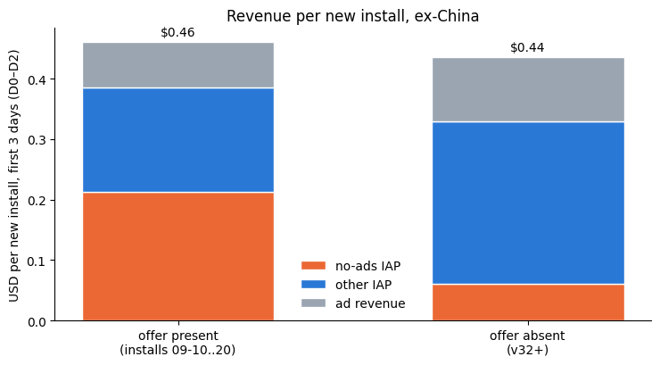

## 2 · The China install spike

### 2a · Size and timing

| install_date China | 09-12 | 09-13 | 09-14 | 09-15 | 09-16 | 09-17 | 09-18 | 09-19 | 09-20 | 09-21 | 09-22 | 09-23 | 09-24 | 09-25 | 09-26 | 09-27 | 09-28 | 09-29 | 09-30 | 10-01 |
| --- | --- | --- | --- | --- | --- | --- | --- | --- | --- | --- | --- | --- | --- | --- | --- | --- | --- | --- | --- | --- |
| rest | 259.0 | 292.0 | 268.0 | 171.0 | 191.0 | 207.0 | 167.0 | 134.0 | 159.0 | 153.0 | 162.0 | 172.0 | 176.0 | 227.0 | 133.0 | 130.0 | 55.0 | 147.0 | 117.0 | 117.0 |
| China | 4.0 | 6.0 | 1.0 | 6.0 | 1.0 | 8.0 | 8.0 | 297.0 | 155.0 | 81.0 | 44.0 | 22.0 | 24.0 | 23.0 | 18.0 | 19.0 | 11.0 | 7.0 | 15.0 | 6.0 |
| China share % | 2.0 | 2.0 | 0.0 | 3.0 | 1.0 | 4.0 | 5.0 | 69.0 | 49.0 | 35.0 | 21.0 | 11.0 | 12.0 | 9.0 | 12.0 | 13.0 | 17.0 | 5.0 | 11.0 | 5.0 |
| China on v29 % | 0.0 | 0.0 | 0.0 | 0.0 | 0.0 | 0.0 | 50.0 | 98.0 | 100.0 | 95.0 | 100.0 | 100.0 | 92.0 | 83.0 | 94.0 | 79.0 | 36.0 | 71.0 | 93.0 | 100.0 |

### 2b · Are they real players, and do they earn anything?

Everyone active since 09-11, China vs the rest.

|  | rest of world | China |
| --- | --- | --- |
| users | 6955 | 891 |
| active_days_per_user | 2.0 | 1.37 |
| minutes_per_user | 30.05 | 28.08 |
| shop_taps_per_user | 0.11 | 0.11 |
| ad_clicks_per_user | 1.08 | 0.05 |
| ad_impressions_per_user | 0.99 | 0.02 |
| IAP_usd_total | 2772.48 | 0.0 |
| ad_usd_total | 380.28 | 0.12 |
| rewarded fill % | 59.75 | 28.31 |

### 2c · What it does to the KPIs

|  | 09-04 | 09-11 | 09-18 | 09-25 |
| --- | --- | --- | --- | --- |
| DAU all | 898.714 | 823.857 | 775.857 | 560.0 |
| DAU ex-CN | 894.0 | 817.714 | 640.286 | 527.143 |
| IAP ARPDAU all | 0.214 | 0.225 | 0.162 | 0.152 |
| IAP ARPDAU ex-CN | 0.216 | 0.227 | 0.196 | 0.162 |
| installs all | 1974 | 1718 | 1754 | 1025 |
| installs ex-CN | 1959 | 1688 | 1119 | 926 |

| group | installs | D1 | D3 | D7 |
| --- | --- | --- | --- | --- |
| rest | 1123 | 25.6 | 8.4 | 4.5 |
| China | 631 | 18.2 | 4.9 | 1.9 |

## 3 · Why ad revenue is low

Break ad revenue per DAU into its parts: **share of DAU that watches any ad × impressions per watcher × revenue per impression**.

|  | 08-21 | 08-28 | 09-04 | 09-11 | 09-18 | 09-25 |
| --- | --- | --- | --- | --- | --- | --- |
| ad $ / DAU | 0.021 | 0.019 | 0.016 | 0.025 | 0.027 | 0.031 |
| % of DAU watching ≥1 ad | 7.351 | 6.582 | 6.695 | 7.6 | 8.3 | 8.618 |
| impressions per watcher | 5.952 | 5.718 | 4.632 | 6.154 | 6.065 | 6.248 |
| eCPM $ | 48.334 | 50.86 | 50.658 | 54.387 | 53.817 | 57.01 |
| impressions per DAU | 0.437 | 0.376 | 0.31 | 0.468 | 0.503 | 0.538 |
| interstitial imps | 87 | 57 | 60 | 50 | 48 | 53 |
| rewarded fill % | 52.249 | 51.514 | 51.259 | 57.959 | 53.979 | 70.588 |
| interstitial loads OK | 2901 | 2089 | 2124 | 1779 | 1767 | 1583 |
| interstitial shown % of loaded | 2.999 | 2.729 | 2.825 | 2.811 | 2.716 | 3.348 |
| interstitial load attempts | 79314 | 55329 | 47341 | 39530 | 41666 | 17511 |
| DNS-fail attempts | 65506 | 36842 | 34138 | 20659 | 10901 | 9977 |

### 3b · Where impressions come from — every one is opt-in rewarded

Last 4 weeks, by `ad_placement`. The only interstitial placements are `interstitial_backup_*` — the fallback when a rewarded ad fails. There is no regular interstitial in the game.

```
Reusing cached data: C:\Users\Admin\Desktop\TinyKnight\parquet\nb15_ad_placements.parquet
          imps     usd
fmt
INTER      214    2.91
REWARDED  8670  475.86
```

|  | placement | fmt | imps | users | usd | share of $ % | eCPM $ |
| --- | --- | --- | --- | --- | --- | --- | --- |
| 0 | acquire_hero | REWARDED | 2174 | 571 | 177.61 | 37.1 | 81.7 |
| 1 | daily_quest | REWARDED | 788 | 229 | 44.17 | 9.2 | 56.1 |
| 2 | key_challenge_BossRush | REWARDED | 630 | 348 | 54.50 | 11.4 | 86.5 |
| 3 | key_challenge_GoldRush | REWARDED | 551 | 308 | 30.72 | 6.4 | 55.8 |
| 4 | flybox_gold | REWARDED | 528 | 177 | 20.98 | 4.4 | 39.7 |
| 5 | lucky_spin | REWARDED | 523 | 172 | 22.65 | 4.7 | 43.3 |
| 6 | summon_gear | REWARDED | 489 | 194 | 23.36 | 4.9 | 47.8 |
| 7 | summon_skill | REWARDED | 363 | 132 | 13.05 | 2.7 | 36.0 |
| 8 | summon_companion | REWARDED | 337 | 124 | 6.58 | 1.4 | 19.5 |
| 9 | game_speed_x2 | REWARDED | 240 | 180 | 22.94 | 4.8 | 95.6 |
| 10 | welcome_back | REWARDED | 217 | 81 | 6.18 | 1.3 | 28.5 |
| 11 | blessing_attack | REWARDED | 214 | 73 | 2.43 | 0.5 | 11.4 |
| 12 | skip_time_research | REWARDED | 180 | 71 | 9.15 | 1.9 | 50.8 |
| 13 | flybox_blessing | REWARDED | 159 | 83 | 6.96 | 1.5 | 43.8 |
| 14 | key_challenge_HoneyWar | REWARDED | 156 | 53 | 5.58 | 1.2 | 35.8 |

### 3c · Ad rewards paid out without an ad impression

`ad_reward` (player received the reward) outnumbers `ad_impression_MAX` by ~25%. If ad-free owners (`skip.ad*` buyers, membership) can claim "watch ad" rewards without watching, every one of those is an impression that never happens.

```
rewards 10,793 vs rewarded impressions 8,670  -> 20% of rewards have no impression
```

| class | users | rewards | impressions | rewards without an impression |
| --- | --- | --- | --- | --- |
| bought a skip.ad SKU | 19 | 141 | 160 | -19 |
| no impressions at all | 404 | 2656 | 0 | 2656 |
| watches ads | 567 | 7996 | 6504 | 1492 |
| total | 990 | 10793 | 6664 | 4129 |

## 4 · IAP — what explains the drop

This week vs the pre-removal baseline (average of 09-04 and 09-11 weeks), all countries (China adds $0 either way).

```
IAP drop $726/wk = no-ads $383 + other IAP $343
  other-IAP drop explained by fewer DAU alone: $311; by lower spend per DAU: $33
```

|  | baseline/wk | this week | change | change % |
| --- | --- | --- | --- | --- |
| iap | 1323.456 | 597.074 | -726.382 | -54.885 |
| noads | 513.845 | 130.94 | -382.905 | -74.518 |
| sale | 311.296 | 0.0 | -311.296 | -100.0 |
| other_iap | 809.611 | 466.134 | -343.477 | -42.425 |
| ads | 122.001 | 113.283 | -8.717 | -7.145 |
| payers | 61.5 | 37.0 | -24.5 | -39.837 |
| DAU | 861.286 | 560.0 | -301.286 | -34.981 |
| DAU ex-CN | 855.857 | 527.143 | -328.714 | -38.408 |
| other IAP $ per DAU ex-CN | 0.135 | 0.126 | -0.009 | -6.522 |

|  | total | payers | top1 | top3 | arppu | top payer % | top 3 % | total excl. top payer |
| --- | --- | --- | --- | --- | --- | --- | --- | --- |
| 09-04 | 1349.1 | 67 | 179.8 | 394.5 | 20.1 | 13.0 | 29.0 | 1169.3 |
| 09-11 | 1297.8 | 56 | 91.2 | 255.6 | 23.2 | 7.0 | 20.0 | 1206.6 |
| 09-18 | 877.6 | 40 | 78.3 | 188.2 | 21.9 | 9.0 | 21.0 | 799.3 |
| 09-25 | 597.1 | 37 | 72.2 | 173.0 | 16.1 | 12.0 | 29.0 | 524.9 |

## 5 · Retention — new installs, ex-China

Share of installs active exactly *k* days later. Cells whose target day is 09-28 (data gap) or after 10-01 are left blank.

| install week | installs | D1 % | D3 % | D7 % | D14 % |
| --- | --- | --- | --- | --- | --- |
| 08-07 | 2097 | 26.0 | 10.8 | 6.0 | 2.9 |
| 08-14 | 2975 | 26.6 | 9.8 | 4.9 | 2.3 |
| 08-21 | 3010 | 26.5 | 9.8 | 4.7 | 2.6 |
| 08-28 | 1943 | 24.6 | 9.4 | 5.6 | 3.2 |
| 09-04 | 1958 | 25.9 | 9.9 | 5.1 | 2.5 |
| 09-11 | 1689 | 26.6 | 9.8 | 6.7 | 3.3 |
| 09-18 | 1123 | 25.6 | 8.4 | 4.8 | NaN |
| 09-25 | 809 | 20.9 | 8.8 | NaN | NaN |

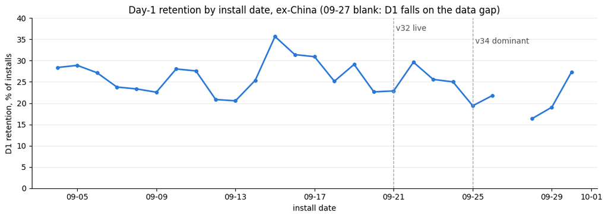

| install_date | 2026-09-04 | 2026-09-05 | 2026-09-06 | 2026-09-07 | 2026-09-08 | 2026-09-09 | 2026-09-10 | 2026-09-11 | 2026-09-12 | 2026-09-13 | 2026-09-14 | 2026-09-15 | 2026-09-16 | 2026-09-17 | 2026-09-18 | 2026-09-19 | 2026-09-20 | 2026-09-21 | 2026-09-22 | 2026-09-23 | 2026-09-24 | 2026-09-25 | 2026-09-26 | 2026-09-27 | 2026-09-28 | 2026-09-29 | 2026-09-30 |
| --- | --- | --- | --- | --- | --- | --- | --- | --- | --- | --- | --- | --- | --- | --- | --- | --- | --- | --- | --- | --- | --- | --- | --- | --- | --- | --- | --- |
| installs | 229 | 277 | 291 | 290 | 287 | 288 | 296 | 301 | 259 | 292 | 268 | 171 | 191 | 207 | 167 | 134 | 159 | 153 | 162 | 172 | 176 | 227 | 133 | 130 | 55 | 147 | 117 |
| D1 | 28.4 | 28.9 | 27.1 | 23.8 | 23.3 | 22.6 | 28.0 | 27.6 | 20.8 | 20.5 | 25.4 | 35.7 | 31.4 | 30.9 | 25.1 | 29.1 | 22.6 | 22.9 | 29.6 | 25.6 | 25.0 | 19.4 | 21.8 | NaN | 16.4 | 19.0 | 27.4 |
| build | 24 | 24 | 24 | 24 | 25 | 25 | 25 | 26.2 | 26.2 | 26.2 | 26.2 | 26.2 | 26.2 | 28 | 29 | 29 | 29 | 29 | 32 | 32 | 33 | 34 | 34 | 34 | 34 | 34 | 34 |

| period campaign | size 09-04..10 | size 09-11..24 | size 09-25..30 | mean 09-04..10 | mean 09-11..24 | mean 09-25..30 |
| --- | --- | --- | --- | --- | --- | --- |
| (unattributed) | 969.0 | 1383.0 | 324.0 | 20.8 | 20.0 | 16.0 |
| GA_TinyKnightfa_A_ROAS_Global_20072026 | 418.0 | 621.0 | 182.0 | 28.0 | 34.0 | 24.2 |
| GA_TinyKnightfa_A_ROAS_Tier1_150926 | NaN | 224.0 | 52.0 | NaN | 35.7 | 23.1 |
| GA_TinyKnightfa_A_ROAS_Tier1_29092026 | NaN | NaN | 34.0 | NaN | NaN | 38.2 |
| Organic | 183.0 | 308.0 | 87.0 | 27.9 | 25.6 | 24.1 |

## 6 · Conclusion

**This week (09-25 … 10-01): $710 total — $597 IAP + $113 ads — vs ~$1,445/week in the two pre-removal weeks (−51%).** DAU 560 (527 ex-China) vs 861; installs 926 ex-China vs ~1,820; payers 37 vs ~62.

- **It is not price.** eCPM is healthy and rising ($48 → $57), and ad $ per DAU actually *doubled* (0.016 → 0.031) as the base shrank to its engaged core.
- **It is reach.** Ads are **100% opt-in rewarded** — the game has no regular interstitials (all 214 interstitial impressions in 4 weeks are the `interstitial_backup_*` fallback). **Only 8.6% of DAU watch any ad on a given day**, ~6 ads each → 0.54 impressions per DAU. `acquire_hero` alone is 37% of ad revenue.
- **20% of ad rewards are paid without an impression**: 10,793 `ad_reward` vs 8,670 rewarded impressions in 4 weeks; **404 users got 2,656 rewards and never saw a single ad** (one user: 431). Not explained by no-ads buyers (19 users, no gap). At current eCPM that is **~$55/week (+50% of ad revenue)** if those were real views — **dev check: is there a skip-ad perk (membership/VIP) or an exploit?**
- Loading has improved: rewarded fill 51% → 71%, and AppLovin DNS-fail retries fell 65k → 10k/week.
- **Levers, in order:** (1) find the reward-without-ad leak; (2) more rewarded placements on high-intent moments like `acquire_hero` / `BossRush` (eCPM $82–87); (3) consider a capped interstitial for non-payers — the only way to move the 91% who never opt in.

### 4 · IAP

- **The $726/week drop = −$383 no-ads + −$343 other IAP.** Of the other-IAP drop, **$311 is just fewer players** (DAU ex-China −38%) and only **$33 is lower spend per player** (0.135 → 0.126 per DAU).
- **So the main driver is the shrinking install base:** UA volume roughly halved — the two FB campaigns and `GA_…ROAS_Tier1_29082026` ended, and the new `…Tier1_29092026` is small (34 installs). Not whale-driven: the top payer is 7–13% of each week.

### 5 · Retention

- **D1 fell to 20.9% for 09-25 week installs, vs 24.6–26.6% for the seven weeks before**; D3 8.8% vs ~9.8%. D7 was stable (4.7–6.7%) through the 09-18 cohort.
- **It is not traffic mix** — D1 fell inside every campaign: ROAS Global 34 → 24%, Tier1_150926 35.7 → 23.1%, unattributed 20 → 16%, Organic 25.6 → 24.1%. **It coincides with v34 becoming the install build (09-25).** ~690 eligible installs, so this needs another week — but **check v34 for an onboarding / crash / first-session regression now.**

### Data quality

- **~18 h with almost no events, 09-28 09:00 → 09-29 03:00 UTC.** Ask devs whether the game server was down; otherwise it is an export gap and 09-28 revenue is missing from GA4 (compare Play Console). All figures are gross, VAT-inclusive outside the US, with no refunds.